# Capability model — robustness to input noise

Cagliari · ELECTRE TRI-B capability classification · 1563 nodes · all parameters held at baseline (see the sensitivity report for parameter-sensitivity results) -- only the input service scores are perturbed. This answers a different question from sensitivity: **given the parameters are right, is the resulting map trustworthy, or is it noise-sensitive?**

## 1. How this analysis works

Holds every parameter fixed at baseline (q_factor, p_factor, λ cut, ELECTRE weights, all upstream config) and adds gaussian noise (σ) to the service scores, clipped to [0,1], repeated many times per σ per node. **Stability** = share of repetitions that assign a node its single most common ("modal") class; 1.0 = solid, 0.5 = coin-flip. This is a structural question, independent of parameter sensitivity: a model can be insensitive to its parameters yet still non-robust to noise, or vice versa.

### Parameters tested

σ ∈ {0.02, 0.05, 0.1} (gaussian noise std-dev added to each service score, in the same [0,1] units as the scores themselves), each repeated 1563 times per capability.

## 2. Results

Mean class stability and share of "shaky" nodes (stability < 0.8), per capability and σ:

| capability | sigma | mean_stability | pct_lt_08 |
| --- | --- | --- | --- |
| care | 0.02 | 0.90 | 19.83 |
|  | 0.05 | 0.78 | 49.71 |
|  | 0.10 | 0.67 | 86.63 |
| nutrition | 0.02 | 0.95 | 9.47 |
|  | 0.05 | 0.87 | 26.49 |
|  | 0.10 | 0.74 | 65.58 |
| restorativeness | 0.02 | 0.97 | 6.40 |
|  | 0.05 | 0.92 | 16.25 |
|  | 0.10 | 0.86 | 29.50 |

Same data as a violin plot, showing the **full distribution** of per-node stability rather than just its mean — a capability whose nodes split into a stable cluster and a coin-flip cluster looks very different from one that is uniformly middling, even if their means match; the dashed line marks the 0.8 "shaky" threshold:

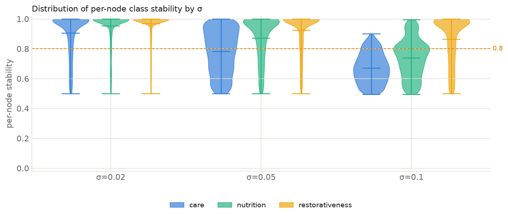

## 3. Conclusions

Mean class stability at σ=0.05: care 0.78; nutrition 0.87; restorativeness 0.92. **care** is the least stable capability here — **50%** of its nodes are unstable (fewer than 80% of noisy repetitions agree on a class). So care classes should be presented with uncertainty, not as hard categories. The QGIS layer (`capability_stability.gpkg`) maps this per node — red = coin-flip, green = solid — so a viewer can see exactly where on the map to trust the classification and where not to.

Generated by `robustness_report.py` from `robustness_node_stability.csv` (produced by `robustness_analysis.py`). Re-running both refreshes every figure.